# R Notebook

Selección de modelos Vemos criterios de comparación de modelos, primero cargamos datos:

```r
library(MASS)
data(Boston)
head(Boston)
```

|  | crim | zn | indus | chas | nox | rm | age | dis | rad | tax | ptratio | black | lstat | medv |
| --- | --- | --- | --- | --- | --- | --- | --- | --- | --- | --- | --- | --- | --- | --- |
| 1 | 0.00632 | 18 | 2.31 | 0 | 0.538 | 6.575 | 65.2 | 4.0900 | 1 | 296 | 15.3 | 396.90 | 4.98 | 24.0 |
| 2 | 0.02731 | 0 | 7.07 | 0 | 0.469 | 6.421 | 78.9 | 4.9671 | 2 | 242 | 17.8 | 396.90 | 9.14 | 21.6 |
| 3 | 0.02729 | 0 | 7.07 | 0 | 0.469 | 7.185 | 61.1 | 4.9671 | 2 | 242 | 17.8 | 392.83 | 4.03 | 34.7 |
| 4 | 0.03237 | 0 | 2.18 | 0 | 0.458 | 6.998 | 45.8 | 6.0622 | 3 | 222 | 18.7 | 394.63 | 2.94 | 33.4 |
| 5 | 0.06905 | 0 | 2.18 | 0 | 0.458 | 7.147 | 54.2 | 6.0622 | 3 | 222 | 18.7 | 396.90 | 5.33 | 36.2 |
| 6 | 0.02985 | 0 | 2.18 | 0 | 0.458 | 6.430 | 58.7 | 6.0622 | 3 | 222 | 18.7 | 394.12 | 5.21 | 28.7 |

Valor medio de viviendas ocupadas en miles.

```r
sd(Boston$medv)
```

```
[1] 9.197104
```

```r
mean(Boston$medv)
```

```
[1] 22.53281
```

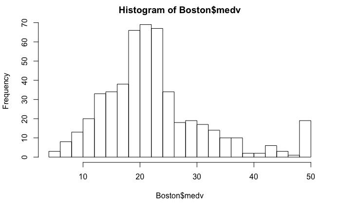

```r
hist(Boston$medv,20)
```

Hay una anomalía en los datos en el valor 50, quitamos estas casas.

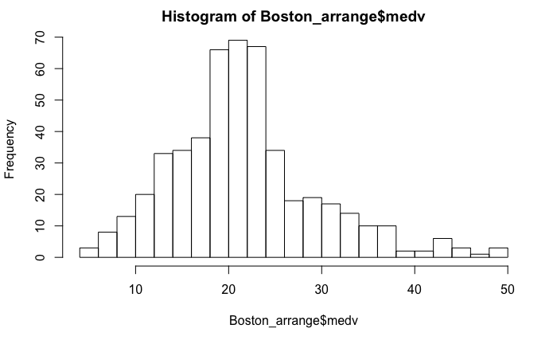

```r
Boston_arrange<-subset(Boston, medv < 50)
hist(Boston_arrange$medv,20)
```

Generamos un modelo sobre todas las variables. Con confint sacamos intervalos de confianza para los coeficientes del modelo

```r
mod <- lm(medv~.,data=Boston_arrange)
summary(mod)
```

```
Call:
lm(formula = medv ~ ., data = Boston_arrange)

Residuals:
     Min       1Q   Median       3Q      Max
-10.3101  -2.3082  -0.5764   1.7472  15.8830

Coefficients:
              Estimate Std. Error t value Pr(>|t|)
(Intercept)  32.229842   4.123534   7.816 3.53e-14 ***
crim         -0.106716   0.026107  -4.088 5.12e-05 ***
zn            0.035313   0.011270   3.133 0.001834 **
indus        -0.043883   0.049811  -0.881 0.378764
chas          0.452209   0.741682   0.610 0.542347
nox         -12.398108   3.056812  -4.056 5.83e-05 ***
rm            3.759453   0.357358  10.520  < 2e-16 ***
age          -0.023679   0.010652  -2.223 0.026681 *
dis          -1.210965   0.160649  -7.538 2.43e-13 ***
rad           0.251302   0.053083   4.734 2.91e-06 ***
tax          -0.013777   0.002999  -4.594 5.57e-06 ***
ptratio      -0.838180   0.105363  -7.955 1.32e-14 ***
black         0.007853   0.002131   3.686 0.000254 ***
lstat        -0.350108   0.042518  -8.234 1.75e-15 ***
---
Signif. codes:  0 ‘***’ 0.001 ‘**’ 0.01 ‘*’ 0.05 ‘.’ 0.1 ‘ ’ 1

Residual standard error: 3.759 on 476 degrees of freedom
Multiple R-squared:  0.7777,    Adjusted R-squared:  0.7716
F-statistic: 128.1 on 13 and 476 DF,  p-value: < 2.2e-16
```

```r
confint(mod)
```

```
                    2.5 %       97.5 %
(Intercept)  24.127260695 40.332422644
crim         -0.158015989 -0.055415835
zn            0.013168478  0.057458158
indus        -0.141759097  0.053992908
chas         -1.005167066  1.909585696
nox         -18.404623198 -6.391593342
rm            3.057258351  4.461648571
age          -0.044608947 -0.002749163
dis          -1.526634641 -0.895296337
rad           0.146996367  0.355607390
tax          -0.019669922 -0.007884954
ptratio      -1.045214507 -0.631145665
black         0.003666419  0.012039909
lstat        -0.433653419 -0.266562418
```

```r
mod_red <- lm(medv~.-age-indus-chas,data=Boston_arrange)
summary(mod_red)
```

```
Call:
lm(formula = medv ~ . - age - indus - chas, data = Boston_arrange)

Residuals:
    Min      1Q  Median      3Q     Max
-9.8749 -2.2377 -0.5142  1.7627 15.3092

Coefficients:
              Estimate Std. Error t value Pr(>|t|)
(Intercept)  33.356056   4.108994   8.118 4.04e-15 ***
crim         -0.106640   0.026115  -4.083 5.20e-05 ***
zn            0.038829   0.011187   3.471 0.000566 ***
nox         -14.849176   2.812464  -5.280 1.97e-07 ***
rm            3.629703   0.348298  10.421  < 2e-16 ***
dis          -1.083990   0.150811  -7.188 2.54e-12 ***
rad           0.274132   0.051111   5.363 1.27e-07 ***
tax          -0.015092   0.002718  -5.553 4.66e-08 ***
ptratio      -0.875497   0.103815  -8.433 3.99e-16 ***
black         0.007686   0.002130   3.608 0.000341 ***
lstat        -0.388141   0.039390  -9.854  < 2e-16 ***
---
Signif. codes:  0 ‘***’ 0.001 ‘**’ 0.01 ‘*’ 0.05 ‘.’ 0.1 ‘ ’ 1

Residual standard error: 3.77 on 479 degrees of freedom
Multiple R-squared:  0.7749,    Adjusted R-squared:  0.7702
F-statistic: 164.9 on 10 and 479 DF,  p-value: < 2.2e-16
```

Calculamos la matriz de correlaciones y la fila de correlaciones respecto a la variable objetivo “medv”

```r
M <- cor(Boston_arrange)
M["medv",]
```

```
       crim          zn       indus        chas         nox          rm         age         dis         rad         tax
-0.45011518  0.40460764 -0.60000523  0.07480347 -0.52445103  0.68663431 -0.49291521  0.36881318 -0.47629559 -0.57244167
    ptratio       black       lstat        medv
-0.51864105  0.36492798 -0.75983749  1.00000000
```

Usamos AIC para comparar ambos modelos, es ligeramente mejor el modelo que tiene todas las variables

```r
AIC(mod)
```

```
[1] 2704.033
```

```r
AIC(mod_red)
```

```
[1] 2704.063
```

```r
BIC(mod)
```

```
[1] 2766.949
```

```r
BIC(mod_red)
```

```
[1] 2754.396
```

Funciones step de selección de variables Se puede automatizar la selección de modelos con la función step. Esta función prueba todos los modelos con distintas variables anidándose aumentando variables ó reduciéndolas. Sigue el proceso en cascada hasta que el criterio deja de aumentar.

Selección por pasos del mejor modelo en función de los atributos elegidos usando el criterio AIC y añadiendo cada vez más variables: (ver página 78 del libro en PDF)

```r
step <- stepAIC(lm(medv~1,data=Boston_arrange),scope =
                  medv~crim+zn+indus+chas+nox+rm+age+dis+tax+ptratio+black+lstat, direction="forward")
```

```
Start:  AIC=2022.21
medv ~ 1

          Df Sum of Sq   RSS    AIC
+ lstat    1   17465.5 12786 1602.2
+ rm       1   14262.3 15989 1711.8
+ indus    1   10890.5 19360 1805.5
+ tax      1    9912.9 20338 1829.7
+ nox      1    8320.5 21930 1866.6
+ ptratio  1    8137.2 22114 1870.7
+ age      1    7349.9 22901 1887.8
+ crim     1    6129.0 24122 1913.3
+ zn       1    4952.3 25299 1936.6
+ dis      1    4114.8 26136 1952.6
+ black    1    4028.6 26222 1954.2
+ chas     1     169.3 30082 2021.5
<none>                 30251 2022.2

Step:  AIC=1602.21
medv ~ lstat

          Df Sum of Sq   RSS    AIC
+ rm       1   2394.40 10391 1502.6
+ ptratio  1   2110.11 10675 1515.8
+ tax      1    898.44 11887 1568.5
+ indus    1    688.44 12097 1577.1
+ crim     1    378.79 12407 1589.5
+ black    1    271.74 12514 1593.7
+ zn       1    259.03 12526 1594.2
+ nox      1    169.04 12616 1597.7
+ chas     1    147.71 12638 1598.5
+ dis      1     64.06 12721 1601.8
<none>                 12786 1602.2
+ age      1      3.46 12782 1604.1

Step:  AIC=1502.61
medv ~ lstat + rm

          Df Sum of Sq     RSS    AIC
+ ptratio  1   1697.44  8693.6 1417.2
```

[output cut: 97 more lines]

```
medv ~ lstat + rm + ptratio + tax + black + dis + nox + age +
    zn + crim

        Df Sum of Sq    RSS    AIC
+ indus  1    63.828 7059.8 1331.2
<none>               7123.6 1333.6
+ chas   1    14.166 7109.4 1334.6

Step:  AIC=1331.2
medv ~ lstat + rm + ptratio + tax + black + dis + nox + age +
    zn + crim + indus

       Df Sum of Sq    RSS    AIC
<none>              7059.8 1331.2
+ chas  1    17.041 7042.7 1332.0
```

```r
step
```

```
Call:
lm(formula = medv ~ lstat + rm + ptratio + tax + black + dis +
    nox + age + zn + crim + indus, data = Boston_arrange)

Coefficients:
(Intercept)        lstat           rm      ptratio          tax        black          dis          nox          age
  26.481257    -0.339638     4.067198    -0.759537    -0.002853     0.007194    -1.208875   -10.080874    -0.027475
         zn         crim        indus
   0.028492    -0.073739    -0.102194
```

```r
step$anova # resultados
```

```
Stepwise Model Path
Analysis of Deviance Table

Initial Model:
medv ~ 1

Final Model:
medv ~ lstat + rm + ptratio + tax + black + dis + nox + age +
    zn + crim + indus

        Step Df    Deviance Resid. Df Resid. Dev      AIC
1                                 489  30250.988 2022.211
2    + lstat  1 17465.49896       488  12785.489 1602.214
3       + rm  1  2394.40407       487  10391.085 1502.606
4  + ptratio  1  1697.44078       486   8693.644 1417.212
5      + tax  1   498.73264       485   8194.911 1390.263
6    + black  1   220.87026       484   7974.041 1378.875
7      + dis  1   178.99930       483   7795.042 1369.750
8      + nox  1   368.69054       482   7426.351 1348.008
9      + age  1   111.23882       481   7315.112 1342.613
10      + zn  1    89.37822       480   7225.734 1338.589
11    + crim  1   102.15444       479   7123.580 1333.613
12   + indus  1    63.82792       478   7059.752 1331.202
```

Vemos que el mejor modelo es el que contempla todas la variables salvo “Chas”.

```r
AIC(step)
```

```
[1] 2723.762
```

Otro modo de escribirlo estableciendo explícitamente el modelo mayor y el menor. También se puede indicar la dirección de evolución con “forward”, “backward” y “both”

```r
fit1 <- lm(medv~crim+zn+indus+chas+nox+rm+age+dis+tax+ptratio+black+lstat,data=Boston_arrange)
fit0 <- lm(medv~1,data=Boston_arrange)
stepAIC(fit1,direction="backward")
```

```
Start:  AIC=1332.02
medv ~ crim + zn + indus + chas + nox + rm + age + dis + tax +
    ptratio + black + lstat

          Df Sum of Sq    RSS    AIC
- chas     1     17.04 7059.8 1331.2
- tax      1     28.79 7071.5 1332.0
<none>                 7042.7 1332.0
- indus    1     66.70 7109.4 1334.6
- zn       1     93.01 7135.7 1336.5
- age      1     95.75 7138.5 1336.6
- crim     1    119.36 7162.1 1338.2
- black    1    158.38 7201.1 1340.9
- nox      1    164.89 7207.6 1341.4
- ptratio  1    741.14 7783.8 1379.0
- dis      1    798.94 7841.7 1382.7
- lstat    1    905.53 7948.2 1389.3
- rm       1   1866.51 8909.2 1445.2

Step:  AIC=1331.2
medv ~ crim + zn + indus + nox + rm + age + dis + tax + ptratio +
    black + lstat

          Df Sum of Sq    RSS    AIC
<none>                 7059.8 1331.2
- tax      1     33.32 7093.1 1331.5
- indus    1     63.83 7123.6 1333.6
- zn       1     91.75 7151.5 1335.5
- age      1     94.62 7154.4 1335.7
- crim     1    121.87 7181.6 1337.6
- nox      1    157.79 7217.5 1340.0
- black    1    162.16 7221.9 1340.3
- ptratio  1    761.04 7820.8 1379.4
- dis      1    800.16 7859.9 1381.8
- lstat    1    904.01 7963.8 1388.2
- rm       1   1889.92 8949.7 1445.4

Call:
lm(formula = medv ~ crim + zn + indus + nox + rm + age + dis +
    tax + ptratio + black + lstat, data = Boston_arrange)

Coefficients:
(Intercept)         crim           zn        indus          nox           rm          age          dis          tax
  26.481257    -0.073739     0.028492    -0.102194   -10.080874     4.067198    -0.027475    -1.208875    -0.002853
    ptratio        black        lstat
  -0.759537     0.007194    -0.339638
```

```r
step$anova # resultados
```

```
Stepwise Model Path
Analysis of Deviance Table

Initial Model:
medv ~ 1

Final Model:
medv ~ lstat + rm + ptratio + tax + black + dis + nox + age +
    zn + crim + indus

        Step Df    Deviance Resid. Df Resid. Dev      AIC
1                                 489  30250.988 2022.211
2    + lstat  1 17465.49896       488  12785.489 1602.214
3       + rm  1  2394.40407       487  10391.085 1502.606
4  + ptratio  1  1697.44078       486   8693.644 1417.212
5      + tax  1   498.73264       485   8194.911 1390.263
6    + black  1   220.87026       484   7974.041 1378.875
7      + dis  1   178.99930       483   7795.042 1369.750
8      + nox  1   368.69054       482   7426.351 1348.008
9      + age  1   111.23882       481   7315.112 1342.613
10      + zn  1    89.37822       480   7225.734 1338.589
11    + crim  1   102.15444       479   7123.580 1333.613
12   + indus  1    63.82792       478   7059.752 1331.202
```

```r
AIC(step)
```

```
[1] 2723.762
```

Ahora probamos con direction=“both”

```r
stepAIC(fit0,direction="both",scope=list(upper=fit1,lower=fit0))
```

```
Start:  AIC=2022.21
medv ~ 1

          Df Sum of Sq   RSS    AIC
+ lstat    1   17465.5 12786 1602.2
+ rm       1   14262.3 15989 1711.8
+ indus    1   10890.5 19360 1805.5
+ tax      1    9912.9 20338 1829.7
+ nox      1    8320.5 21930 1866.6
+ ptratio  1    8137.2 22114 1870.7
+ age      1    7349.9 22901 1887.8
+ crim     1    6129.0 24122 1913.3
+ zn       1    4952.3 25299 1936.6
+ dis      1    4114.8 26136 1952.6
+ black    1    4028.6 26222 1954.2
+ chas     1     169.3 30082 2021.5
<none>                 30251 2022.2

Step:  AIC=1602.21
medv ~ lstat

          Df Sum of Sq   RSS    AIC
+ rm       1    2394.4 10391 1502.6
+ ptratio  1    2110.1 10675 1515.8
+ tax      1     898.4 11887 1568.5
+ indus    1     688.4 12097 1577.1
+ crim     1     378.8 12407 1589.5
+ black    1     271.7 12514 1593.7
+ zn       1     259.0 12526 1594.2
+ nox      1     169.0 12616 1597.7
+ chas     1     147.7 12638 1598.5
+ dis      1      64.1 12721 1601.8
<none>                 12786 1602.2
+ age      1       3.5 12782 1604.1
- lstat    1   17465.5 30251 2022.2

Step:  AIC=1502.61
medv ~ lstat + rm

          Df Sum of Sq     RSS    AIC
```

[output cut: 173 more lines]

```
- black    1    162.16 7221.9 1340.3
- ptratio  1    761.04 7820.8 1379.4
- dis      1    800.16 7859.9 1381.8
- lstat    1    904.01 7963.8 1388.2
- rm       1   1889.92 8949.7 1445.4

Call:
lm(formula = medv ~ lstat + rm + ptratio + tax + black + dis +
    nox + age + zn + crim + indus, data = Boston_arrange)

Coefficients:
(Intercept)        lstat           rm      ptratio          tax        black          dis          nox          age
  26.481257    -0.339638     4.067198    -0.759537    -0.002853     0.007194    -1.208875   -10.080874    -0.027475
         zn         crim        indus
   0.028492    -0.073739    -0.102194
```

```r
step$anova # resultados
```

```
Stepwise Model Path
Analysis of Deviance Table

Initial Model:
medv ~ 1

Final Model:
medv ~ lstat + rm + ptratio + tax + black + dis + nox + age +
    zn + crim + indus

        Step Df    Deviance Resid. Df Resid. Dev      AIC
1                                 489  30250.988 2022.211
2    + lstat  1 17465.49896       488  12785.489 1602.214
3       + rm  1  2394.40407       487  10391.085 1502.606
4  + ptratio  1  1697.44078       486   8693.644 1417.212
5      + tax  1   498.73264       485   8194.911 1390.263
6    + black  1   220.87026       484   7974.041 1378.875
7      + dis  1   178.99930       483   7795.042 1369.750
8      + nox  1   368.69054       482   7426.351 1348.008
9      + age  1   111.23882       481   7315.112 1342.613
10      + zn  1    89.37822       480   7225.734 1338.589
11    + crim  1   102.15444       479   7123.580 1333.613
12   + indus  1    63.82792       478   7059.752 1331.202
```

```r
AIC(step)
```

```
[1] 2723.762
```

Los tres resultados anteriores dan como mejor modelo el mismo.

Verificamos el ajuste de este modelo, pintando sus residuos y verificando que sean normales, viendo su AIC. En este caso los residuos tienen un fuerte sesgo hacia la derecha que indica que el modelo no está siendo muy adecuado.

```r
mod <- lm(medv ~ lstat + rm + ptratio + tax + black + dis + nox + age +  zn + crim + indus,data= Boston_arrange)
mod
```

```
Call:
lm(formula = medv ~ lstat + rm + ptratio + tax + black + dis +
    nox + age + zn + crim + indus, data = Boston_arrange)

Coefficients:
(Intercept)        lstat           rm      ptratio          tax        black          dis          nox          age
  26.481257    -0.339638     4.067198    -0.759537    -0.002853     0.007194    -1.208875   -10.080874    -0.027475
         zn         crim        indus
   0.028492    -0.073739    -0.102194
```

```r
extractAIC(mod,scale=0)
```

```
[1]   12.000 1331.202
```

Pintamos el RSS -> Los residuos.

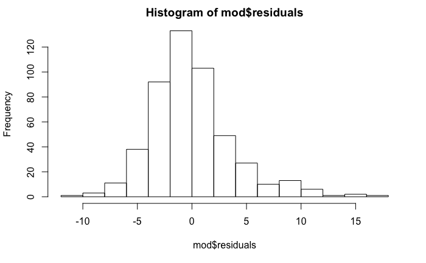

```r
hist(mod$residuals)
```

Deberían seguir una distribución normal para consideralos como adecuados.

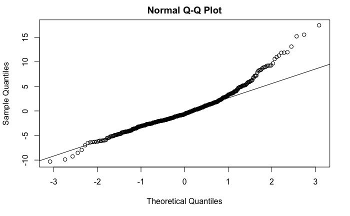

```r
qqnorm(mod$residuals)
qqline(mod$residuals)
```

```r
shapiro.test(mod$residuals) #hay un fuerte sesgo hacia la derecha y  no es normal la distribución
```

```
    Shapiro-Wilk normality test

data:  mod$residuals
W = 0.94197, p-value = 6.575e-13
```

```r
summary(mod)
```

```
Call:
lm(formula = medv ~ lstat + rm + ptratio + tax + black + dis +
    nox + age + zn + crim + indus, data = Boston_arrange)

Residuals:
    Min      1Q  Median      3Q     Max
-10.309  -2.311  -0.633   1.669  17.433

Coefficients:
              Estimate Std. Error t value Pr(>|t|)
(Intercept)  26.481257   4.031974   6.568 1.33e-10 ***
lstat        -0.339638   0.043412  -7.824 3.32e-14 ***
rm            4.067198   0.359546  11.312  < 2e-16 ***
ptratio      -0.759537   0.105810  -7.178 2.71e-12 ***
tax          -0.002853   0.001899  -1.502 0.133753
black         0.007194   0.002171   3.314 0.000991 ***
dis          -1.208875   0.164238  -7.360 8.06e-13 ***
nox         -10.080874   3.084161  -3.269 0.001159 **
age          -0.027475   0.010855  -2.531 0.011690 *
zn            0.028492   0.011431   2.492 0.013024 *
crim         -0.073739   0.025670  -2.873 0.004252 **
indus        -0.102194   0.049159  -2.079 0.038163 *
---
Signif. codes:  0 ‘***’ 0.001 ‘**’ 0.01 ‘*’ 0.05 ‘.’ 0.1 ‘ ’ 1

Residual standard error: 3.843 on 478 degrees of freedom
Multiple R-squared:  0.7666,    Adjusted R-squared:  0.7613
F-statistic: 142.7 on 11 and 478 DF,  p-value: < 2.2e-16
```